# Deep Reinforcement Learning

En la clase anterior vimos cómo podíamos simplificar la iteración sobre todos los estados utilizando el algoritmo **Q-learning**, sin embargo , aunque sólo anotemos los estados visitados el número de combinaciones puede seguir siendo extremadamente alta. Por ejemplo, en el juego del Go hay $3^{361}$ combinaciones posibles, más que átomos en el universo (según dicen!). De hecho, en **algunos entornos**, que ya hemos visto, la **combinación de estados posibles** es, en la práctica, **infinita** (en teoría finita, en la práctica realmente nom ya que están representados por bits). Si os paráis a pensarlo, hasta ahora hemos trabajado con entornos discretos, finitos. Sin embargo, **¿Qué ocurre cuando los entornos tienen estados continuos** (por ej: el ángulo de rotación de la nave espacial) **?**.

[figure not shown]

Una posible solución es *discretizar* el espacio de entrada, es decir, convertir nuestros estados de su forma continua a su forma discreta, por ejemplo, dividir el ángulo de la nave espacial en "cajitas" de 10 grados. Aún así, esto nos lleva a otra cuestión, que és, ¿Y hasta cuanto discretizo un estado? ¿10 grados está bien? ¿o es mejor 0.05 grados?. E incluso se añade otro problema y es que, en espacios continuos puede darse el caso de que dos estados muy similares necesiten de acciones totalmente distintas.

[figure not shown]

Como solución a todos estos problemas podemos usar una **representación no lineal** que transforme el estado en el que nos encontramos en una acción, o el par estado-accion en un valor. Esto, en el campo del machine learning se conoce como un *problema de regresion*. Y resulta que una de las mejores herramientas a la hora de realizar este tipo de tareas son las famosas **Redes Neuronales**. Y esta idea de incorporar una red neuronal a problemas de aprendizaje por refuerzo es lo que llevó a **DeepMind** a ser adquirida por Google por la friolera de 500 millones de $ en 2014. Y lo que ha permitido los hitos que mencionábamos en la primera clase sobre **AlphaGo** y **AlphaStar** (https://www.bloomberg.com/news/articles/2014-01-27/google-buys-u-k-artificial-intelligence-company-deepmind).

# Deep Learning y Redes Neuronales: breve introducción

Si bien el **deep learning** en sí es un campo **muy amplio** y totalmente abierto a investigación intentaremos entender los fundamentos más básicos que nos permitan aplicar redes neuronales al campo del aprendizaje por refuerzo.

La idea principal que subyace detrás de las redes neuronales es intentar **simular el funcionamiento de las neuronas**. Cada neurona de nuestro cerebro tiene un **potencial de activación**, cuando a una neurona le llega una señal se desencadena una variación electrica dentro de ella. Si esta variación es lo suficientemente potente y se alcanza el potencial de activación la neurona en cuestión generará una nueva señal que será transmitida por sus axones hasta las siguientes neuronas. Así, sucesivamente, es como se transmite una señal en nuestro cerebro.

[figure not shown]

Las **redes neuronales artificiales** están formadas por cientos de nodos o neuronas interconectadas entre sí generalmente en forma de capas. El esquema general de una red neuronal es:

- **Input Layer**: o capa de entrada
- **Hidden Layers**: o capas intermedias u ocultas
- **Output Layers**: o capas de salida
- **Pesos**: Cada unidad se conecta a otra por un "peso". Un valor positivo o negativo. Cuanto más alto el valor más fuerte será la influencia de una neurona sobre la otra.

[figure not shown]

La información (la señal eléctrica) en el esquema tradicional de una red neuronal artificial fluye de la capa de entrada a la capa de salida, esto es lo que se conoce como una red **feedforward**. En la imagen de arriba sería de izquierda a derecha. Una vez llega a la salida obtenemos un resultado, que puede ser, desde un valor entre 0 y 1, hasta un array multidimensional de floats. **Técnicamente**: cuando hablamos de la **arquitectura de una red neuronal** (https://keras.io/layers/core/) hablamos, por un lado, de la forma que tienen las capas, y por otro de cómo se conectan dichas capas entre sí. Hay muchos tipos de arquitecturas, algunas de las más conocidas son las **fully connected** en la que todas las neuronas de una capa están conectadas con todas las neuronas de la capa siguiente, otras como las **convolucionales** utilizan capas con forma de malla y filtros para obtener información espacial de los datos de entrada, este último tipo de arquitectura es la usada en el reconocimiento de imágenes, por ejemplo. Al igual que las neuronas cerebrales tienen potenciales de activación, las unidades de las Redes Artificiales tienen una **función de activación** (https://keras.io/activations/), que puede ser de muchos tipos también: ReLu, Leaky-ReLu, TanH, Sigmoid...

[figure not shown]

**¿Y cómo "aprende" una red neuronal?**, la respuesta rápida es **"de forma supervisada"**, es decir, cada vez que la red nos da una salida la "corregimos" y le decimos si lo ha hecho "bien o mal" y además "cuánto de bien o cuánto de mal", a continuación **la red reajusta sus pesos** en una fase que se conoce como **backpropagation**. Se conoce con ese nombre ya que en esta fase el flujo de información información, y por tanto, el reajuste del que hablamos, se da desde la salida hacia la entrada. **Técnicamente**: Esa diferencia entre lo que la red nos devuelve y lo que nosotros esperamos de ella se calcula a través de una **función de pérdida**: (https://keras.io/losses/) algunas de ellas son: "Crossentropy", o "Mean Squared Error". Y a la pregunta de ¿Y cómo se actualizan los pesos? la respuesta es: a través de un **algoritmo de optimización**: algunos de los más conocidos son: "Stochastic Gradient Descent" o "SGD, "Adam"... (https://keras.io/optimizers/).

Algunos recursos muy interesantes para aprender más sobre redes neuronales son la we de playground tensorflow, o el video explicativo de 3 blue 1 brown al respecto.

https://playground.tensorflow.org/

```python
from IPython.display import YouTubeVideo
YouTubeVideo('aircAruvnKk', width=720, height=480)
```

[video not shown]

Los entresijos de todos los conceptos que acabamos de ver son **bastante complejos** y se escapan al objetivo de la clase de hoy. De momento basta con entender que **una red neuronal es un modelo matemático que aprende de forma supervisada a través del método "ensayo y error"**.

# Aplicando Redes Neuronales: Cross-Entropy y Deep Q-Learning

En la clase de hoy vamos a ver dos formas de implementar redes neuronales entornos de Reinforcement Learning. Dos de los algoritmos principales que veremos hoy son:

- **Cross-Entropy**: Un método muy sencillo pero muy eficaz.
- **Deep Q-learning**: Un método más complejo, pero mucho más poderoso.

# Método Cross-entropy

- Por cada **época**:
  - Por cada **episodido**:
    - Elegir acciones siguiendo una política (epsilon-greedy, random, prob-distribution...)
    - Anotar cada par observación-acción.
    - Calcular la recompensa total.
  - Quedarse con los pares observación-acción de los mejores episodios (recompensa más alta).
  - Entrenar la red con las observaciones como input y las acciones como output.
  - Repetir nueva época hasta conformidad con el resultado.

```python
import matplotlib.pyplot as plt
from numpy import array, expand_dims, squeeze, argmax
from numpy.random import choice
from keras.callbacks import Callback


class History(Callback):
    """
    Esta clase, hereda de la clase Callback, irá acumulando la información sobre el entrenamiento de nuestra red.
    Es necesaria ya que tras cada epoca entrenamos la red con los mejores resultados.
    Los métodos de esta clase son estándar e irán acumulando la info cada vez que la época empiece/acabe
    """

    def on_train_begin(self, logs=None):
        if not hasattr(self, 'epoch'):
            self.epoch = []
            self.history = {}

    def on_epoch_end(self, epoch, logs=None):
        logs = logs or {}
        self.epoch.append(epoch)
        for k, v in logs.items():
            self.history.setdefault(k, []).append(v)


def unpack_obs_acts(episodes):

    '''
    Toma una lista de episodios y devuelve las observaciones del estado (x) y su acción esperada (y).
    @ episodes: list of NamedTuples: Lista con la info de los episodios

    '''
    observations, actions = [], []

    # por cada episodio
    for ep in episodes:

        # Desempaquetamos los valores de las observaciones
        observations.extend(map(lambda step: step.observations, ep.steps))

        # Desempaquetamos los valores de las acciones
        actions.extend(map(lambda step: step.action, ep.steps))

    # Devolvemos las observaciones y sus acciones esperadas
    return array(observations), array(actions)

def plot_history(history):

    '''
    Imprime en una gráfica la evolución del entrenamiento de la red.
    @ history: objeto de keras devuelto tras el entrenamiento (model.fit)
    '''

    # Plot training & validation accuracy values
    plt.plot(history.history['acc'])
    plt.plot(history.history['val_acc'])
    plt.title('Model accuracy')
    plt.ylabel('Accuracy')
    plt.xlabel('Epoch')
    plt.legend(['Train', 'Test'], loc='upper left')
    plt.show()
    # Plot training & validation loss values
    plt.plot(history.history['loss'])
    plt.plot(history.history['val_loss'])
    plt.title('Model loss')
    plt.ylabel('Loss')
    plt.xlabel('Epoch')
    plt.legend(['Train', 'Test'], loc='upper left')
    plt.show()
```

### Iniciamos el Entorno: FrozenLake-v0

```python
from collections import namedtuple
import gym

'''
PASO 0: Creamos el entorno, determinamos el número de épocas y el número de episodios a realizar en cada época.
Por cada época se ejecuta, primero, un número determinado de episodios para a continuación entrenar al agente
con los resultados de esas simulaciones
'''

# Creamos el entorno
env = gym.make('FrozenLake-v0')

# Definimos el número de épocas y episodios
# Creamos una instancia de historia que nos almacena los datos del avance del entrenamiento de la NN
EPOCS = 30
EPISODES = 5000
history = History()

TRAINING_BATCH_SIZE = 128
TRAINING_EPOCH = 32
TRAINING_VALIDATION_SPLIT = 0.1

# Creamos dos objetos namedtuple que nos
Episode = namedtuple('Episode', field_names=['reward', 'steps'])
EpisodeStep = namedtuple('EpisodeStep', field_names=['observations', 'action'])

print('[*] Iniciando Simulación')
print('[*] Número de épocas:', EPOCS)
print('[*] Número de episodios por época:', EPISODES)
```

```
[*] Iniciando Simulación
[*] Número de épocas: 30
[*] Número de episodios por época: 5000
```

### Creamos nuestra red neuronal (nuestro Agente)

```python
from keras.models import Sequential
from keras.layers import Dense, ReLU
from keras.optimizers import Adam
from keras.losses import CategoricalCrossentropy
from keras.utils import to_categorical

'''
PASO 1: Creamos nuestro agente, en este caso es tan sencillo como una NN que toma como entrada las observaciones
y devuelve la acción a realizar. Está compuesta por una capa de entrada, una capa oculta fully connected de 128 nodos
y una capa de salida de 4 nodos (correspondiente a las 4 posibles acciones del entorno)
'''
# Inicializamos la red neuronal
net = Sequential(name='Fully Connected Network')

# Añadimos la capa oculta y le indicamos que el input
# debe corresponder al espacio de observación
net.add(Dense(
    128,
    input_shape=(env.observation_space.n,),
    name='Hidden')
       )

# Indicamos una función de activación para esa capa oculta de tipo ReLU
net.add(ReLU(name='Activation'))

# Añadimos una última capa de salida con 4 nodos y función de activación softmax.
# Esta función de activación nos devuelve la probabilidad de ejecución de cada acción
net.add(Dense(
    env.action_space.n,
    activation='softmax',
    name='Output')
       )

# Obtenemos información de esta red
# net.summary()

# La compilamos para su posterior entrenamiento con el optimizador Adam y
# la función de pérdida de tipo CategoricalCrossentropy
net.compile(
    optimizer=Adam(),
    loss=CategoricalCrossentropy(),
    metrics=['acc'])
```

## Algoritmo Cross-Entropy

**CUIDADO**: Ejecutar esta casilla puede llevar mucho tiempo en CPU

```python
# Iniciamos el loop sobre las épocas
for epoc in range(EPOCS):

    # Creamos una lista donde almacenar los resultados de los episodios de esta época:
    # - Recompensa final
    # - Observaciones
    # - Acciones
    lista_episodios = []

    '''
    PASO 2: por cada época ejecutamos un número determinado de episodios.
    Cada episodio consiste en una simulación sobre el entorno que termina cuando el agente alcanza un estado final.
    '''

    # Iniciamos el loop sobre los episodios
    for e in range(EPISODES):

        # Inicializamos la recompensa total del entorno a 0
        ep_reward = 0

        # Creamos una lista donde almacenar los pares
        # observación/acción de cada paso ejecutado en este episodio
        ep_steps = []

        # Reseteamos el entorno y obtenemos la primera observación
        # Esta primera observación, en este entorno, es == 0, correspondiente a la casilla de inicio
        # done representa si el episodio ha finalizado o no
        obs = env.reset()
        done = False

        '''
        PASO 3: mientras el episodio no haya acabado (se ha alcanzado un estado final)
        se ejecutan acciones en el entorno.
        '''

        # Ejecutamos acciones en el entorno mientras el episodio no haya acabado
        while not done:

            # One-Hot-Encoding sobre la observación, es decir, transformamos uno de los 16
            # estados del entorno, representado con un integer, en un array de 15 ceros y 1 uno
            # este último posicionado en el índice del array correspondiente a dicho integer.
            # Ej.: obs = 2 --> obs_vector = [0,0,1,0,0,0.....,0]
            obs_vector = to_categorical(
                obs,
                num_classes=env.observation_space.n
            )

            # Las redes neuronales en Keras están diseñadas para acoger batches (conjuntos) de entradas
            # Puesto que en este caso le pasamos una única entrada de tamaño (16,) debemos incluir una dimensión más
            # Pasando de un vector (16,) a un tensor (1, 16)
            obs_batch = expand_dims(obs_vector, axis=0)

            '''
            PASO 4: el agente (la NN) recibe las observaciones del entorno y devuelve las distribución
            de probabilidad de las acciones a realizar
            '''

            # Lo mismo sucede con la salida, por ello desempaquetamos el único vector de probabilidades de acción
            # devuelto por la red (posicion 0), cada acción tiene una probabilidad de ser la acción "más acertada",
            # a medida que el entrenamiento avance la elección de dicha acción será cada vez más "segura"
            action_prob_vector = net.predict(obs_batch)[0]

            # Tomamos de nuestra distribución de probabilidades de acción una de ellas
            # de forma ponderada a su probabilidad.
            action = choice(len(action_prob_vector), p = action_prob_vector)

            # De nuevo la acción elegida es un integer, que es lo que admite el
            # entorno para ejecutar un paso (acción) sobre él, sin embargo, a la hora del entrenamiento
            # necesitamos almacenar este dato como vector para el cálculo de la función de pérdida.
            action_vector = to_categorical(
                action,
                num_classes= env.action_space.n
            )

            '''
            PASO 5: ejecutamos la acción elegida en el entorno y recogemos la información que éste nos devuelve
            '''

            # El entorno nos devuelve la observación correspondiente al nuevo estado alcanzado,
            # la recompensa de alcanzar dicho estado y si se trata de un estado final o no.
            obs, reward, done, _ = env.step(action)

            # Almacenamos el vector de observaciones y la acción correspondiente
            # que nuestra red ha ejecutado al pasarle esa observación
            # EpisodeStep es una namedtuple creada al principio
            step = EpisodeStep(obs_vector, action_vector)
            ep_steps.append(step)

            # A la recompensa del episodio le sumamos la recibida por la ejecución de este paso
            # En este entorno todos los estados devuelven una recompensa final salvo el estado final objetivo
            # que devuelve +1, por lo que se convierte en 0+0+0+0+0+....+(1) (si hemos alcanzado el objetivo)
            ep_reward += reward


        '''
        PASO 6: almacenamos la información de este episodio en el batch:
            - Recompensa total.
            - Pasos: cada paso compuesto por:
                - las observaciones del agente
                - sus acciones correspondientes
        '''

        # Episode es una namedtuple creada al principio
        # Almacenamos este episodio en la lista de episodios
        ep = Episode(ep_reward, ep_steps)
        lista_episodios.append(ep)

    print('[*] Época', epoc + 1, '/', EPOCS, 'finalizada [*]')

    '''
    PASO 7: filtrar los episodios en los que el agente ha alcanzado el objetivo (reward == 1).
    Nos interesa solo entrenar la red en los episodios que han tenido éxito.
    '''

    # Obtenemos una lista únicamente con los episodios cuya recompensa final sea distinta de 0
    # en este caso la única opción es que dicha recompensa sea de +1
    win_eps = [ep for ep in lista_episodios if ep.reward > 0]
    print('# Episodios ejecutados con éxito:', len(win_eps) , '/', EPISODES)

    # Sanity check: entrenamos únicamente si el agente ha alcanzado en alguna ocasión el objetivo
    # es decir, si la lista de episodios con éxito no está vacía.
    if win_eps:

        # Desempaquetamos los pares observación/acción que nos han llevado al objetivo
        x_obs, y_actions = unpack_obs_acts(win_eps)

        '''
        PASO 8: Usar los pares observación/acción de cada paso ejecutado para entrenamiento de la red neuronal.
        La entrada de la red será el vector de observación y su etiqueta o salida esperada la acción realizada.
        '''
        # Guardamos los datos de entrenamiento en el objeto history.
        # Reservamos un porcentaje de los datos para validación del modelo
        # en el proceso de entrenamiento
        # No confundir las epochs del entrenamiento con las épocas de la simulación
        net.fit(
            x = x_obs,
            y = y_actions,
            batch_size=TRAINING_BATCH_SIZE,
            epochs=TRAINING_EPOCH,
            validation_split=TRAINING_VALIDATION_SPLIT,
            callbacks=[history],
            verbose=0
        )

print('[*] Simulación finalizada')
```

```
[*] Época 1 / 30 finalizada [*]
# Episodios ejecutados con éxito: 81 / 5000
[*] Época 2 / 30 finalizada [*]
# Episodios ejecutados con éxito: 145 / 5000
[*] Época 3 / 30 finalizada [*]
# Episodios ejecutados con éxito: 209 / 5000
[*] Época 4 / 30 finalizada [*]
# Episodios ejecutados con éxito: 270 / 5000
[*] Época 5 / 30 finalizada [*]
# Episodios ejecutados con éxito: 409 / 5000
[*] Época 6 / 30 finalizada [*]
# Episodios ejecutados con éxito: 465 / 5000
[*] Época 7 / 30 finalizada [*]
# Episodios ejecutados con éxito: 597 / 5000
[*] Época 8 / 30 finalizada [*]
# Episodios ejecutados con éxito: 716 / 5000
[*] Época 9 / 30 finalizada [*]
# Episodios ejecutados con éxito: 904 / 5000
[*] Época 10 / 30 finalizada [*]
# Episodios ejecutados con éxito: 1002 / 5000
[*] Época 11 / 30 finalizada [*]
# Episodios ejecutados con éxito: 1194 / 5000
[*] Época 12 / 30 finalizada [*]
# Episodios ejecutados con éxito: 1297 / 5000
[*] Época 13 / 30 finalizada [*]
# Episodios ejecutados con éxito: 1544 / 5000
[*] Época 14 / 30 finalizada [*]
# Episodios ejecutados con éxito: 1650 / 5000
[*] Época 15 / 30 finalizada [*]
# Episodios ejecutados con éxito: 1828 / 5000
[*] Época 16 / 30 finalizada [*]
# Episodios ejecutados con éxito: 1896 / 5000
[*] Época 17 / 30 finalizada [*]
# Episodios ejecutados con éxito: 2084 / 5000
[*] Época 18 / 30 finalizada [*]
# Episodios ejecutados con éxito: 2189 / 5000
[*] Época 19 / 30 finalizada [*]
# Episodios ejecutados con éxito: 2207 / 5000
[*] Época 20 / 30 finalizada [*]
# Episodios ejecutados con éxito: 2307 / 5000
[*] Época 21 / 30 finalizada [*]
# Episodios ejecutados con éxito: 2422 / 5000
[*] Época 22 / 30 finalizada [*]
# Episodios ejecutados con éxito: 2426 / 5000
[*] Época 23 / 30 finalizada [*]
# Episodios ejecutados con éxito: 2501 / 5000
[*] Época 24 / 30 finalizada [*]
# Episodios ejecutados con éxito: 2544 / 5000
[*] Época 25 / 30 finalizada [*]
# Episodios ejecutados con éxito: 2527 / 5000
[*] Época 26 / 30 finalizada [*]
# Episodios ejecutados con éxito: 2591 / 5000
[*] Época 27 / 30 finalizada [*]
# Episodios ejecutados con éxito: 2625 / 5000
[*] Época 28 / 30 finalizada [*]
# Episodios ejecutados con éxito: 2637 / 5000
[*] Época 29 / 30 finalizada [*]
# Episodios ejecutados con éxito: 2761 / 5000
[*] Época 30 / 30 finalizada [*]
# Episodios ejecutados con éxito: 2715 / 5000
[*] Simulación finalizada
```

### Analizamos el entrenamiento

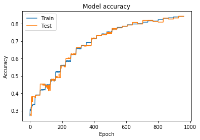

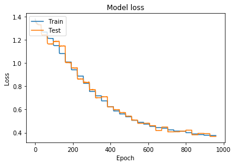

```python
plot_history(history)
```

### Guardamos el modelo

```python
from os import path, mkdir

network = net
weights_name = 'cross_entropy.h5'
weights_folder = 'weights'
weights_path = weights_folder + '/' + weights_name

if path.isfile(weights_path):
    raise Exception("Ya existe un modelo con el nombre {} en la carpeta {}".format(weights_name, weights_folder))
else:
    if not path.exists(weights_folder): mkdir(weights_folder)
    network.save(weights_path)
    print ("Modelo Guardado!")
```

```
Modelo Guardado!
```

## Veamos cómo se comporta el agente paso a paso

### Cargamos el modelo

```python
from keras.models import load_model

# Recrea exactamente el mismo modelo solo desde el archivo
net = load_model('weights/cross_entropy.h5')
```

```python
from keras.utils import to_categorical
from numpy import expand_dims, argmax
import gym

env = gym.make('FrozenLake-v0', is_slippery=True)

obs = env.reset()
done = False

while not done:

    input()
    env.render()

    obs = to_categorical(
        obs,
        num_classes=env.observation_space.n
    )
    obs_vector = expand_dims(obs, axis=0)


    action_prob = net.predict(obs_vector)[0]
    action = argmax(action_prob)
    obs, _, done, _ = env.step(action)


print('#### FINISH ####')
```

```
SFFF
FHFH
FFFH
HFFG

  (Left)
SFFF
FHFH
FFFH
HFFG

  (Left)
SFFF
FHFH
FFFH
HFFG

  (Left)
SFFF
FHFH
FFFH
HFFG

  (Up)
SFFF
FHFH
FFFH
HFFG

  (Up)
SFFF
FHFH
FFFH
HFFG

  (Down)
SFFF
FHFH
FFFH
HFFG

  (Left)
SFFF
FHFH
FFFH
HFFG
#### FINISH ####
```

# Deep Q-learning o DQN

El algoritmo DQN fue presentado en 2013 por DeepMind https://arxiv.org/abs/1312.5602 y aplicaba una idea radical, ¿Qué ocurre si integramos redes neuronales dentro del algoritmo Q-learning? Recordemos que Q-learning se basa en lo siguiente:

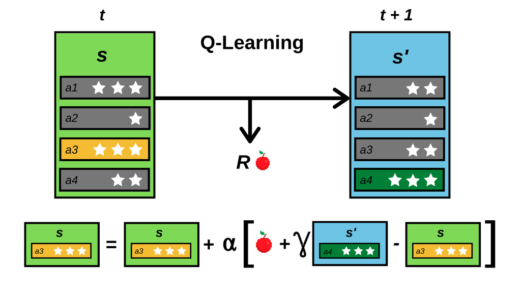

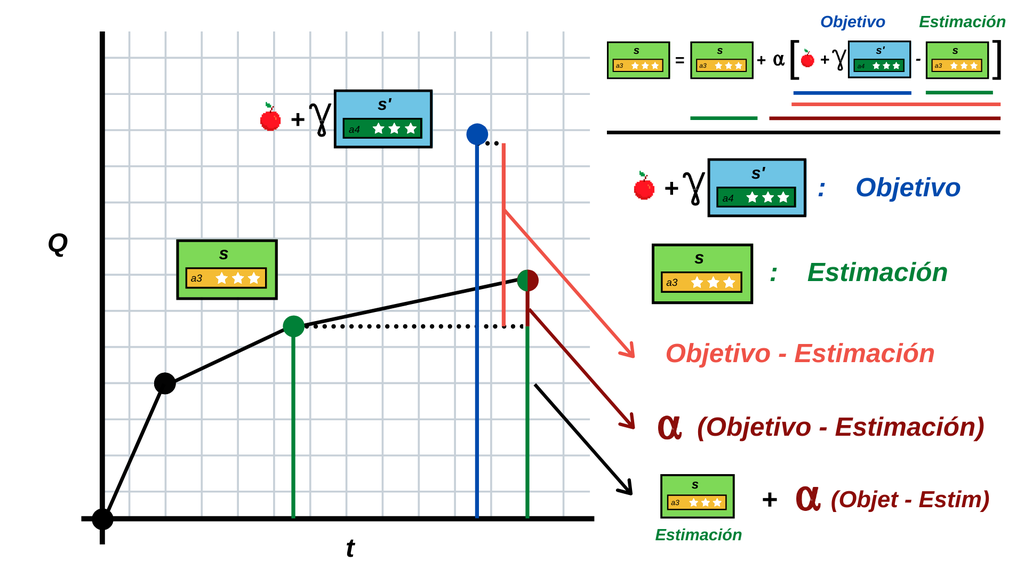

Se les ocurrió que los valores de las acciones **Q** de cada estado fueran **establecidas por dos redes neuronales gemelas**: una encargándose de la estimación del estado actual (que es la red que entrenamos, la caja verde) y otra idéntica encargándose de los valores de Q en el estado alcanzado s' (la caja azul). Pero ¿Por qué dos redes neuronales idénticas pudiendo usar una?

Vamos a explicarlo siguiendo el esquema de arriba, nuestro objetivo, hablando "burro", es que el punto verde se aproxime al punto azul (para eso aplicamos Q learning), si sólo tuviéramos una red tras cada paso de entrenamiento actualizáramos no sólo la caja verde (acercando el punto verde al punto azul) sino que también actualizaríamos la caja azul (moviendo el punto azul a otra parte) por tanto, se convertiría en un pez que se muerde la cola: la caja verde se actualiza, moviendo el punto verde hacia el punto azul, pero la caja azul también se movería (porque estamos usando la misma red para las dos cajas) moviendo el punto azul a otra parte. Esto hace que el entrenamiento sea muy inestable, por eso, **una de los grandes "eurekas" del dqn** es mantener la red de la cajita azul "quieta" o "congelada" mientras usamos una gemela para ir actualizando los pesos de la otra red.

[figure not shown]

## Funciones útiles

### Generar nuestra Red

```python
from keras.models import Sequential
from keras.layers import Dense
from keras.optimizers import Adam
from keras.losses import MeanSquaredError
from keras.utils import to_categorical

def q_network():

    '''
    Creamos nuestro agente, en este caso es tan sencillo como una NN que toma como entrada el estado
    y devuelve la acción a realizar. Está compuesta por una capa de entrada, una capa oculta fully connected de 128 nodos
    y una capa de salida de 2 nodos (correspondiente a las 2 posibles acciones del entorno cartpole)
    '''
    # Inicializamos la red neuronal
    net = Sequential(name='Fully-Connected-Network')

    # Añadimos la capa oculta y le indicamos que el input
    # debe corresponder al espacio de observación
    # Inicializamos los pesos de forma aleatoria uniformemente distribuida
    # Indicamos una función de activación para esa capa oculta de tipo ReLU

    net.add(Dense(
        128,
        input_shape=(ENV.observation_space.shape),
        name='Hidden',
        kernel_initializer='random_uniform',
        bias_initializer='zeros',
        activation='relu'
            )
        )

    # Añadimos una última capa de salida con 2 nodos y función de activación relu.
    # Esta función de activación nos devuelve la Q de cada acción en el estado introducido en el input

    net.add(Dense(
        ENV.action_space.n,
        name='Output',
        kernel_initializer='random_uniform',
        bias_initializer='zeros',
        activation='relu')
       )

    # Obtenemos información de esta red
    net.summary()

    # La compilamos para su posterior entrenamiento con el optimizador Adam y
    # la función de pérdida de tipo MeanSquaredError() típica de ejercicios de regresión (como este)
    # Y utilizada por DeepMind en su paper sobre DQN

    net.compile(
        optimizer=Adam(),
        loss=MeanSquaredError(),
        metrics=['acc'])

    return net
```

### Funciones política $\epsilon$-greedy

```python
from numpy import argmax
from random import random

def get_action_and_value_epsilon_greedy(q_values):

    '''
    Ejecuta una política epsilon-greedy para seleccionar la acción a realizar
    @ q_values: list --> Lista con los valores de Q predichos por la red neuronal
    '''

    # Actuar random
    if random() < EPSILON:

        action, action_q_value = get_random_action_and_value(q_values)

    # Actuar Greedy:
    else:

        action, action_q_value = get_best_action_and_value(q_values)


    return action, action_q_value

def get_best_action_and_value(q_values):

    '''
    Devuelve la acción con el Q más alto y su valor (Q)
    @ q_values: list --> Lista con los valores de Q predichos por la red neuronal
    '''

    best_action = argmax(q_values) # 0 ó 1
    best_q_value = q_values[best_action] # Q más alto

    return best_action, best_q_value


def get_random_action_and_value(q_values):

    '''
    Devuelve una acción aleatoria y su valor (Q)
    @ q_values: list --> Lista con los valores de Q predichos por la red neuronal
    '''

    random_action = ENV.action_space.sample()
    q_value_random_action = q_values[random_action]

    return random_action, q_value_random_action
```

### Función para ejecutar episodios de prueba

```python
from keras.utils import to_categorical
from numpy import expand_dims, argmax
import gym

def reward_from_greedy_episode(network, render=False):

    '''
    Ejecutamos la red en el entorno y obtenemos la recompensa final
    acumulada de ese entorno.
    '''

    # Iniciamos el entorno
    environment = gym.make('CartPole-v0')
    # Obtenemos la primera observación
    obs = environment.reset()
    # Indicamos que el episodio NO ha acabado
    done = False
    # Iniciamos el contador de recompensas a 0
    total_rew = 0

    # Mientras el episodio no haya acabado
    while not done:

        # Transoformamos una observación a un BATCH de una única observación
        obs_vector = expand_dims(obs, axis=0)
        # Obtenemos el Q de las acciones para el estado actual
        q_actions = network.predict(obs_vector)[0]
        # Tomamos la acción con mayor Q --> política greedy
        action = argmax(q_actions)
        # ejecutamos la acción en el entorno y obtenemos el estado alcanzado,
        # la recompensa y si el episodio ha terminado
        obs, rew, done, _ = environment.step(action)
        # acumulamos la recompensa obtenida a la recompensa total
        total_rew += rew
        # renderizamos el frame if True
        if render: environment.render()

    # Al terminar cerramos el entorno
    environment.close()

    # Devolvemos la recompensa total
    return total_rew
```

### Creamos el objeto memoria del algoritmo DQN

```python
from collections import deque, namedtuple
from random import sample
from numpy import array

class memory_replay:

    '''
    Objeto que acumula los siguientes datso en cada paso sobre el entorno:
    - El estado actual en un momento t
    - La acción realizada en ese estado en el momento t
    - El estado alcanzado en el momento t+1
    - La recompensa obtenida por pasar del estado actual al estado alcanzado
    - Un parámetro True/False que determina si el estado alcanzado es un estado terminal (si el episodio ha terminado)
    '''

    def __init__(self, length):

        '''
        Creamos una lista especial (deque) en la que almacenar los parámetros mencionados antes
        Para mejor organización creamos una tupla con nombres para acceder más fácilmente a cada parámetro
        '''

        self.memory_buffer = deque([], maxlen=length)
        self.mem_vector = namedtuple(
            'mem_vector',
            field_names = ['actual_state', 'action', 'next_state', 'reward', 'done']
        )


    def memorize(self, actual_state, action, next_state, reward, done):

        '''
        Almacena cada parámetro en una tupla con nombres y esa tupla en el deque
        '''

        vector = self.mem_vector(
            actual_state = actual_state,
            action = action,
            next_state = next_state,
            reward = reward,
            done = done
        )

        self.memory_buffer.append(vector)

    def reset(self):

        '''
        formatea el buffer de memoria
        '''

        self.memory_buffer.clear()

    def buffer_size(self):

        '''
        Devuelve el número de instancias guardadas hasta el momento
        '''

        return len(self.memory_buffer)

    def get_batch(self, n):

        '''
        Devuelve, de entre todas las instancias almacenadas, un conjunto aleatorio de:
        - Array con los estados actuales
        - Array con las acciones realizadas en esos estados
        - Array con los estados alcanzados por realizar esas acciones en esos estados actuales
        - Array con las recompensas obtenidas por alcanzar dichos estados
        - Array con valores True/False que indican si el episodio se ha terminado en el estado alcanzado
        @ n: int --> Número de instancias que queremos devolver
        '''

        # Sanity Check: evitamos pedir más instancias de las que tenemos almacenadas

        if n > len(self.memory_buffer):

            raise Exception("No hay suficientes instancias: se solicitaron {} y hay {}".format(n , len(self.memory_buffer)) )

        # Creamos otra namedtuple temporal para organizar los arrays mencionados dentro de un único objeto

        mem_batch = namedtuple(
            'mem_batch',
            field_names = ['actual_states', 'actions', 'next_states', 'rewards', 'dones']
        )

        # Tomamos de la memoria un número aleatorio n de instancias

        instances = sample(self.memory_buffer, n)

        # De esas instancias extraemos: sus estados actuales, acciones, estados alcanzados, recompensas
        # y si el episodio terminó o no en el estado alcanzado

        actual_state_sample = array([instance.actual_state for instance in instances])  # Array con los estados actuales
        action_sample = array([instance.action for instance in instances]) # Array con las acciones realizadas en esos estados
        next_state_sample = array([instance.next_state for instance in instances]) # Array con los estados alcanzados
        reward_sample = array([instance.reward for instance in instances]) # Array con las recompensas obtenidas
        done_sample = array([instance.done for instance in instances]) # Array True/False si el episodio ha terminado

        # Empaquetamos los arrays en un único objeto para mejorar la transcripción del código

        batch = mem_batch(
            actual_states = actual_state_sample,
            actions = action_sample,
            next_states = next_state_sample,
            rewards = reward_sample,
            dones = done_sample
        )

        # Devolvemos el Batch

        return batch
```

## ALGORITMO DQN

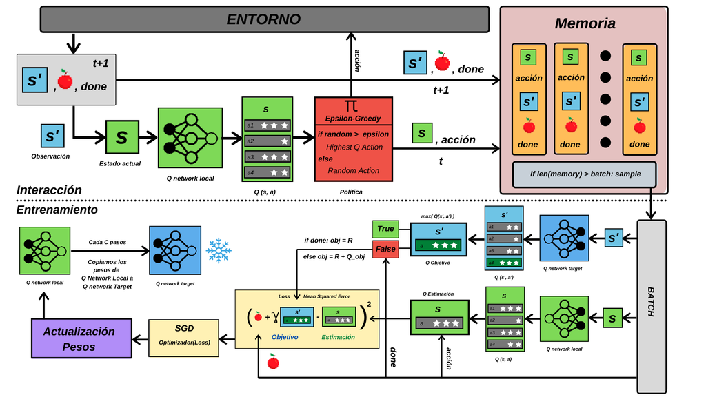

```python
from numpy import expand_dims, copy, mean
from keras.losses import mean_squared_error
import gym

'''
PASO 0: Creamos el entorno, determinamos el número de épocas y el número de episodios a realizar en cada época.
Creamos Epsilon y su factor de descuento. Determinamos el tamaño del Batch de entrenamiento. Y finalmente
determinamos Gamma.

'''

# Creamos el entorno
ENV = gym.make('CartPole-v0')

# Definimos el número de épocas y episodios
EPOCS = 20
EPISODES = 50

# Definimos Epsilon (que guía la política epsilon-greedy)
# Y como se irá reduciendo con el tiempo
EPSILON = 1
EPSILON_DECAY = 0.05
EPSILON_MIN = 0.01

# Definimos el tamaño del Batch que usaremos en la fase de entrenamiento
# y el número de épocas que se entrenará la red sobre ese Batch
TRAINING_BATCH_SIZE = 128
TRAINING_EPOCH = 32
# TRAINING_VALIDATION_SPLIT = 0.1

# Factor Gamma de Descuento (en clases anteriores vimos que es una forma de
# reducir las expectativas de recompensa que esperamos obtener a largo plazo)
GAMMA = 0.9

print('[*] Iniciando Simulación')
print('[*] Número de épocas:', EPOCS)
print('[*] Número de episodios por época:', EPISODES)

# Creamos las dos redes "gemelas" que definen las estimaciones de Q en s (Q_network_local)
# y las estimaciones de Q en s' (Q_network_target)
q_network_local = q_network()
q_network_target = q_network()

# Inicializamos la memoria
memory = memory_replay(20000)

# Una lista vacía donde almacenar todo el progreso de la red en el entorno de pruebas
training_rewards = []

'''
PASO 1: INTERACCIÓN
Por cada época se ejecuta, primero, un número determinado de episodios, tras cada episodio se determina si hay
suficientes instancias para entrenar la red "local", si es así iniciamos el entrenamiento de esa red. Al terminar
el episodio actualizamos la red "objetivo".
'''

for epoc in range(EPOCS):

    print("We are at epoc:", epoc+1, "Epsilon", EPSILON)

    # Reducción de epsilon tras cada época
    if EPSILON > EPSILON_MIN:
        EPSILON -= (EPSILON*EPSILON_DECAY)

    # Reiniciamos la memoria a 0
    memory.reset()

    # Una lista vacía donde almacenar el progreso de la red en el entorno de pruebas tras cada época
    epoc_rewards = []

    # Por cada episodio dentro de la época actual
    for episode in range(EPISODES):

        # Determinamos que el episodio NO ha acabado
        episode_is_done = False

        # Reseteamos el entorno y obtenemos nuestra primera observación (observación == estado)
        actual_state = ENV.reset()

        # Mientras el episodio no haya terminado
        while not episode_is_done:

            # Ampliamos la dimensión de las observaciones para que puedan ser procesadas por la red.
            # Recordemos que las redes en Keras admiten CONJUNTOS de instancias y NO Instancias sueltas.
            # Por Ejemplo: la observación actual (== estado actual) podría ser en este entorno:
            # (-0.00512, 1.25848, 0.222658, 28.54845) --> variables continuas (nos "da igual" qué representa cada valor)
            # la observación actual tiene un "shape" de (4,) pero keras solo acepta BATCHES (conjuntos de observaciones)
            # por lo que debemos transformar su "shape" a (1, 4) lo cual se traduce como un BATCH de UNA ÚNICA INSTANCIA (4,)
            # es decir, un conjunto de instancias formado por UNA ÚNICA INSTANCIA.

            actual_state_batch = expand_dims(actual_state, 0)

            # Obtenemos el valor de Q de las acciones en el estado acual gracias a neustra q_network_local
            # De nuevo Keras nos devuelve un CONJUNTO de PREDICCIONES, como sólo hemos "pasado" una observación
            # obtenemos tan sólo una predicción, de ahí que nos quedemos con la primera (y única) '[0]'

            q_values_actual_state = q_network_local.predict(actual_state_batch)[0]

            # Obtenemos la acción a realizar siguiendo una política Epsilon-Greedy

            selected_action, q_selected_action = get_action_and_value_epsilon_greedy(q_values_actual_state)

            # Una vez seleccionada la acción a realizar la aplicamos sobre el entorno y obtenemos
            # el estado alcanzado, la recompensa de transición, y si el episodio ha terminado

            next_state, reward, episode_is_done, _ = ENV.step(selected_action)

            # Guardamos todos los valores en nuetra memoria para usarlos en el entrenamiento

            memory.memorize(actual_state, selected_action, next_state, reward, episode_is_done)

            # El estado alcanzado es ahora el estado actual, y repetimos el loop hasta que termine el episodio.

            actual_state = next_state


        '''
        PASO 1: ENTRENAMIENTO
        Tras terminar la fase de interacción llega la fase de entrenamiento donde entrenamos UNA de las dos redes.
        La red a entrenar es SIEMPRE la local, la red OBJETIVO no se actualiza (aún) ya que de ella obtenemos las
        expectativas de recompensa a futuro Q(s', a(max)). Si actualizáramos las dos a la vez nuestro "objetivo"
        cambiaría con cada entrenamiento y eso desestabilizaría dicho entrenamiento. Este último punto es algo más
        difícil de entender, pero es la clave del algoritmo DQN, por lo que os aconsejo que intentéis interiorizarlo
        para comprender la clase entera.

        '''

        # Entrenamos sólo si hay instancias suficientes
        if memory.buffer_size() >= TRAINING_BATCH_SIZE:

            # Obtenemos un batch aleatorio de instancias recolectadas durante la fase de interacción
            batch = memory.get_batch(TRAINING_BATCH_SIZE)

            actual_states = batch.actual_states
            actions = batch.actions
            next_states = batch.next_states
            rewards = batch.rewards
            dones = batch.dones

            # Obtenemos los valores de Q para el vector de estados actuales. Por cada estado actual obtenemos
            # una lista con dos valores (para el entorno CARTPOLE), esos dos valores determinan el Q de cada una
            # de las 2 acciones posibles dentro de cada uno de esos estados.
            q_estimation = q_network_local.predict(actual_states)

            # Obtenemos los valores de Q para el vector de estados alcanzados. Por cada estado alcanzado obtenemos
            # una lista con dos valores (para el entorno CARTPOLE), esos dos valores determinan el Q de cada una
            # de las 2 acciones posibles dentro de cada uno de esos estados.
            q_target = q_network_target.predict(next_states)

            # De esos 2 Q nos quedamos con el más alto siguiendo las directrices del algoritmo Q-learning
            q_target = q_target.max(1)

            # Si el estado alcanzado del que obtenemos Q es un estado FINAL entonces su Q = 0 !!!
            # Recordamos: Q es el valor de una acción, determina la cantidad de recompensa que esperamos
            # obtener a largo plazo desde un estado cualquiera realizando dicha acción. Al ser un estado TERMINAL
            # la expectativa de recompensas DEBE SER 0, ya que el episodio HA TERMINADO, y no podemos obtener
            # nuevas recompensas.
            q_target[dones] = 0 # donde done == True, q_target = 0

            # Finalmente aplicamos BELLMAN para determinar el objetivo.
            # Recordamos: lo llamamos objetivo porque idealmente queremos que nuestra red LOCAL (ESTIMACIÓN)
            # nos de como resultado dicho OBJETIVO. Por esto precisamente NO actualizamos la red OBJETIVO tras
            # cada episodio, porque necesitamos que el OBJETIVO sea EL MISMO durante la fase de entrenamiento
            # de la red LOCAL, para no "liar" a la red local.

            target = rewards + GAMMA * q_target # lista de valoroes objetivo para cada instancia

            # El siguiente paso idealmente sería algo así:
            # loss = MEANSQUAREDERROR(target - q_estimation(actions))
            # q_network_local.backpropagation(loss)
            # Pero Keras NO permite esto de una forma relativamente sencilla, por lo que, para no hacer más complejo
            # el código usaremos un "SMART-TRICK" jugando con la función de pérdida "loss":

            # Vamos a tomar el vector de estimaciones de Q para los estados actuales, los cual nos dan el valor de Q
            # para cada una de las dos acciones posibles para cada uno de esos estados, y vamos a cambiar el valor de Q
            # de la acción que realizamos en su momento por el valor del objetivo.

            Y = copy(q_estimation) # copia de los resultados de q_network_local para los estados actuales del batch

            for index, action in enumerate(actions): # Por cada acción dentro del conjunto de acciones del batch

                Y[index, action] = target[index] # Cambiamos el valor Y para la acción realizada para que sea = target

            # Al introducir de nuevo durante el
            # entrenamiento el estado actual como INPUT obtendremos los valores de Q para el estado actual, dichos valores
            # son idénticos a los que teníamos en q_estimation, idénticos todos, salvo el de la acción ejecutada que ahora
            # es igual al target del estado alcanzado. Por tanto, cuando se aplique la función de pérdida "MSE"
            # que recordemos que es (target - q_estimation(actions))^2 --> (target - q_estimation) será 0 para todas las
            # acciones menos para la acción realizada por lo que los pesos se actualizarán UNICAMENTE para la acción realizada.

            q_network_local.fit(actual_states,
                         Y,
                         batch_size=TRAINING_BATCH_SIZE,
                         epochs=TRAINING_EPOCH,
                         verbose=0)

            # Al final, tras el entrenamiento, copiamos los pesos de la q_network_local a la q_network_target

            q_network_target.set_weights(q_network_local.get_weights())

        '''
        OPCIONAL: controlar el rendimiento de nuestra red (nuestro agente) en un entorno de pruebas

        '''

        # Probamos nuestra red en el entorno durante un episodio
        episode_reward = reward_from_greedy_episode(q_network_local, render=False) # min: 0, max: 200

        # Incorporamos la recompensa de prueba del episodio al historial de la época
        epoc_rewards.append(episode_reward)

    # Incorporamos las recompensas de prueba de cada epoca al historial total
    training_rewards.extend(epoc_rewards)

    print("The best reward at EPOC {} is {} with mean {}".format(epoc+1, max(epoc_rewards), mean(epoc_rewards)))
```

```
[*] Iniciando Simulación
[*] Número de épocas: 20
[*] Número de episodios por época: 50
Model: "Fully-Connected-Network"
_________________________________________________________________
Layer (type)                 Output Shape              Param #
=================================================================
Hidden (Dense)               (None, 128)               640
_________________________________________________________________
Output (Dense)               (None, 2)                 258
=================================================================
Total params: 898
Trainable params: 898
Non-trainable params: 0
_________________________________________________________________
Model: "Fully-Connected-Network"
_________________________________________________________________
Layer (type)                 Output Shape              Param #
=================================================================
Hidden (Dense)               (None, 128)               640
_________________________________________________________________
Output (Dense)               (None, 2)                 258
=================================================================
Total params: 898
Trainable params: 898
Non-trainable params: 0
_________________________________________________________________
We are at epoc: 1 Epsilon 1
The best reward at EPOC 1 is 200.0 with mean 27.68
We are at epoc: 2 Epsilon 0.95
The best reward at EPOC 2 is 200.0 with mean 128.24
We are at epoc: 3 Epsilon 0.9025
The best reward at EPOC 3 is 200.0 with mean 146.82
We are at epoc: 4 Epsilon 0.857375
The best reward at EPOC 4 is 200.0 with mean 146.92
We are at epoc: 5 Epsilon 0.81450625
The best reward at EPOC 5 is 200.0 with mean 179.64
We are at epoc: 6 Epsilon 0.7737809375
The best reward at EPOC 6 is 200.0 with mean 155.96
We are at epoc: 7 Epsilon 0.735091890625
```

[output cut: 12 more lines]

```
The best reward at EPOC 13 is 200.0 with mean 160.36
We are at epoc: 14 Epsilon 0.5133420832795051
The best reward at EPOC 14 is 200.0 with mean 155.84
We are at epoc: 15 Epsilon 0.48767497911552987
The best reward at EPOC 15 is 200.0 with mean 132.64
We are at epoc: 16 Epsilon 0.4632912301597534
The best reward at EPOC 16 is 200.0 with mean 185.56
We are at epoc: 17 Epsilon 0.4401266686517657
The best reward at EPOC 17 is 200.0 with mean 133.32
We are at epoc: 18 Epsilon 0.4181203352191774
The best reward at EPOC 18 is 200.0 with mean 187.24
We are at epoc: 19 Epsilon 0.39721431845821853
The best reward at EPOC 19 is 200.0 with mean 195.84
We are at epoc: 20 Epsilon 0.3773536025353076
The best reward at EPOC 20 is 200.0 with mean 188.4
```

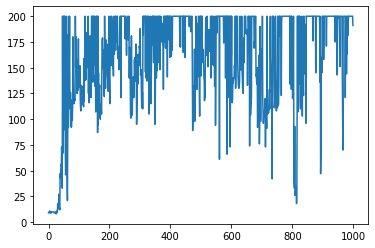

```python
import matplotlib.pyplot as plt
plt.plot(training_rewards)
```

### Guardamos el modelo

```python
network = q_network_local
weights_name = 'dqn.h5'
weights_folder = 'weights'
weights_path = weights_folder + '/' + weights_name

if path.isfile(weights_path):
    raise Exception("Ya existe un modelo con el nombre {} en la carpeta {}".format(weights_name, weights_folder))
else:
    if not path.exists(weights_folder): mkdir(weights_folder)
    network.save(weights_path)
    print ("Modelo Guardado!")
```

```
Modelo Guardado!
```

### Probamos el modelo

```python
from keras.models import load_model

# Recrea exactamente el mismo modelo desde el archivo
dqn_network = load_model('weights/dqn.h5')
reward_from_greedy_episode(dqn_network, render = True)
```

```
200.0
```